# Querying OBIS, GBIF, and Fishbase with AphiaIDs

Author

Stephen Formel

Published

April 18, 2024

## What?

I recently attended a meeting to discuss Species Distribution Models, or SDMs. The attendees emphasized the importance of [GBIF](https://www.gbif.org/), [OBIS](https://obis.org/), and [FishBase](https://fishbase.mnhn.fr/search.php) for informing SDMs. One of the challenges that was discussed was how to query taxa consistently and efficiently across these databases.

Here I demonstrate how to use [AphiaIDs](https://www.marinespecies.org/about.php#what_is_aphia), the identifier used by the [World Registry of Marine Species (WoRMS)](https://www.marinespecies.org/), to query and link the data from OBIS, GBIF, and FishBase.

**The basic idea:**

1. Query WoRMS to identify your AphiaID(s).
2. Query WoRMS to get the equivalent Fishbase ID(s).
3. Query GBIF to get the equivalent identifier(s) from the [GBIF taxonomic backbone](https://www.gbif.org/dataset/d7dddbf4-2cf0-4f39-9b2a-bb099caae36c).
4. Query OBIS. GBIF, and Fishbase for your taxa of interest.

#### Why?

Data are often distributed across multiple repositories. Often, the first step to answering a question is to coordinate the data. All of the aforementioned databases are working to resolve this challenge, but it will probably be some time before science completely figures out how to seamlessly serve all data all the time!

#### How?

By Unknown author - NOAA FishWatch, Public Domain, https://commons.wikimedia.org/w/index.php?curid=22626272

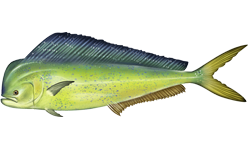

We’ll look at mahi-mahi, AKA Dorado, ([*Coryphaena hippurus*](https://www.marinespecies.org/aphia.php?p=taxdetails&id=126846)) in the EEZ of Puerto Rico.

**Geometry**

Let’s start by creating the geometry for the area we wish to query! We’ll grab the EEZ from [MarineRegions.org](https://marineregions.org/) and simplify it into a convex hull. Then we’ll turn it into Well-Known Text (WKT) so it can be used in the API queries.

```r
library(dplyr)

#Make convex hull of PR EEZ from MarineRegions.org.
PR_EEZ <- mregions2::gaz_geometry(x = 33179) %>%
  sf::st_convex_hull() %>%
  sf::st_as_text() %>%
  wk::wkt() %>%
  wk::wk_orient()
```

> Note: The GBIF API reads `clockwise` WKT as a hole in geometry. But the `sf` package outputs clockwise WKT by default. The functions from the `wk` package are the easiest way I’ve found to reverse the winding order the WKT.

##### Step 1. Query WoRMS to identify your AphiaID(s).

You can [search WoRMS through your web browser](https://www.marinespecies.org/aphia.php?p=search), using scientific or common names. Here is the landing page for *Coryphaena hippurus*:

> https://www.marinespecies.org/aphia.php?p=taxdetails&id=126846

You can see the AphiaID at the end of the link: `126846`. There is also an R package, `worrms` that can help execute this query:

```r
AphiaID <- worrms::wm_name2id(name = "Coryphaena hippurus")
```

> Note that we put the AphiaID into an object named `AphiaID` that we will use below.

##### Step 2. Query WoRMS to get the equivalent Fishbase ID(s).

Here we use the `httr2` package to query the WoRMS API for the fishbase identifier. I don’t think this is possible through the `worrms` package. If you’re not familiar with APIs and how they work, John Waller at GBIF wrote a [blog post](https://data-blog.gbif.org/post/gbif-api-beginners-guide/) that’s a good place to start.

```r
library(httr2)

fishbaseID <- request(base_url = 'https://www.marinespecies.org/rest/AphiaExternalIDByAphiaID/') %>%
  req_url_path_append(AphiaID) %>%
  req_url_query(`type` = 'fishbase') %>%
  req_perform() %>%
  resp_body_json() %>%
  unlist()
```

##### Step 3. Query GBIF to get the equivalent identifier(s) from GBIF

GBIF aligns the data to a custom taxonomic database known as the [GBIF taxonomic backbone](https://www.gbif.org/dataset/d7dddbf4-2cf0-4f39-%209b2a-bb099caae36c). Although most AphiaIDs map to the backbone, I’m not 100% positive that all of them do. This dissonance is a known problem in the world of taxonomic databases and smart people from all over the world are working on removing this challenge.

If you only have one species, or aren’t feeling very code savvy, you can also view this information by putting the API call into a web browser:

https://api.gbif.org/v1/species?datasetKey=2d59e5db-57ad-41ff-97d6-11f5fb264527&sourceId=urn:lsid:marinespecies.org:taxname:126846

But if you are feeling code savvy:

```r
library(httr2)

sourceId <- paste0('urn:lsid:marinespecies.org:taxname:', AphiaID)

response <- request(base_url = 'https://api.gbif.org/v1/species') %>%
  req_url_query(`datasetKey` = '2d59e5db-57ad-41ff-97d6-11f5fb264527',
                `sourceId` = 'urn:lsid:marinespecies.org:taxname:159222') %>%
  req_perform() %>%
  resp_body_json()

GBIF_backboneID <- response$results[[1]]$nubKey
```

##### Step 4. Query OBIS. GBIF, and FishBase for your taxa of interest.

###### OBIS

Let’s start with OBIS, since it aligns to WoRMS and therefore uses AphiaIDs.

```r
library(robis)

obis_results <- robis::occurrence(taxonid = AphiaID,
                  geometry = PR_EEZ)
```

Let’s take a moment to create the citations for the four datasets that contributed to this query, and for OBIS. We will publish these citatoins at the bottom of this post. We’ll follow the guidance in the [OBIS Manual](https://manual.obis.org/policy.html#section-4.-conditions-of-use):

```r
OBIS_metadata <- obis_results$dataset_id %>% unique() %>%
  robis::dataset(datasetid = .)

#generate citations

OBIS_citations <- list()

for(i in 1:nrow(OBIS_metadata)){

OBIS_citations[[i]] <- robis::generate_citation(title = OBIS_metadata[i,]$title,
                         published = OBIS_metadata[i,]$published,
                         url = OBIS_metadata[i,]$url,
                         contacts = OBIS_metadata[i,]$contacts %>% as.data.frame())

} %>% unlist()

# Make citation for OBIS itself:

date_accessed <- Sys.Date()
query_title <- "Occurrence records of Coryphaena hippurus (Linnaeus, 1758) in the Puerto Rico EEZ [Dataset] "

OBIS_citation <- paste0("OBIS (2024) ",
                       query_title,
                       '(Available: Ocean Biodiversity Information System. Intergovernmental Oceanographic Commission of UNESCO. www.obis.org. Accessed:',
                       date_accessed,
                       ')'
                       )
```

###### Then GBIF…

GBIF data can be accessed through the API without obtaining a DOI, but the best practice is to [mint a DOI](https://www.gbif.org/citation-guidelines) once you are convinced that your query is final. If you continue to filter your results after downloading, you can always mint a [derived dataset DOI](https://www.gbif.org/citation-guidelines#derivedDatasets).

```r
library(rgbif)

# download without DOI, to explore the data.
gbif_results <- rgbif::occ_data(taxonKey = GBIF_backboneID,
                                geometry = PR_EEZ) %>%
  .[["data"]]
```

```r
#download with DOI, so I can cite the data.

rgbif::occ_download(
  user = 'sformel',
  email = 'sformel@usgs.gov',
  pwd = rstudioapi::askForPassword(prompt = "GBIF Password"),
  pred_and(pred("taxonKey", GBIF_backboneID),
           pred("geometry", PR_EEZ)
  ))
```

The message returned by the above code includes a download key and shows the suggested citation. I can also find this information under the downloads linked to my profile on gbif.org. Create the citation to print below:

```r
GBIF_citation <- rgbif::gbif_citation(x = occ_download_meta(key = '0197864-240321170329656'))[['download']]
```

###### …and finally FishBase:

Now let’s get some relevant trait info from Fishbase. FishBase has tons of information in it! So to make it a bit simpler, I’m only going to grab data about mahi-mahi reproduction.

```r
library(rfishbase)

repro_table <- rfishbase::species_list(SpecCode = fishbaseID) %>%
  reproduction() %>%
  select(Species,
         ReproMode,
         Fertilization,
         Spawning,
         RepGuild1,
         RepGuild2,
         ParentalCare)
```

#### Visualize Results

Let’s map the results, showing which data came from OBIS, which data came from OBIS, and displaying it alongside select reproductive traits from FishBase.

```r
library(ggplot2)
library(sf)
library(rnaturalearth)

#Get an outline of Puerto Rico for mapping
PR <- rnaturalearth::ne_countries(country = 'Puerto Rico',
                                  returnclass = 'sf',
                                  scale = 'large')

# Select needed columns
obis_select <- obis_results %>%
               select(occurrenceID,
                      decimalLatitude,
                      decimalLongitude) %>%
  mutate(Source = 'OBIS')

gbif_select <- gbif_results %>%
               select(occurrenceID,
                      decimalLatitude,
                      decimalLongitude) %>%
  mutate(Source = 'GBIF')

# Join Data from GBIF and OBIS

mahi_joined <- rbind(obis_select,
                         gbif_select)

map_plot <- ggplot(PR) +
  geom_sf() +
  geom_point(data = mahi_joined,
             inherit.aes = FALSE,
             aes(x = decimalLongitude,
                 y = decimalLatitude,
                 color = Source)) +

  #everything below here only serves to stylize the plot

  scale_color_manual(values = c('orange', 'skyblue')) +
  theme_bw(base_size=14) +
  guides(color = guide_legend(override.aes = list(size = 5))) +
  coord_sf(xlim = c(-64, -70))
```

Map of *Coryphaena hippurus* occurrences in the Puerto Rico EEZ. Data sourced from OBIS and GBIF.

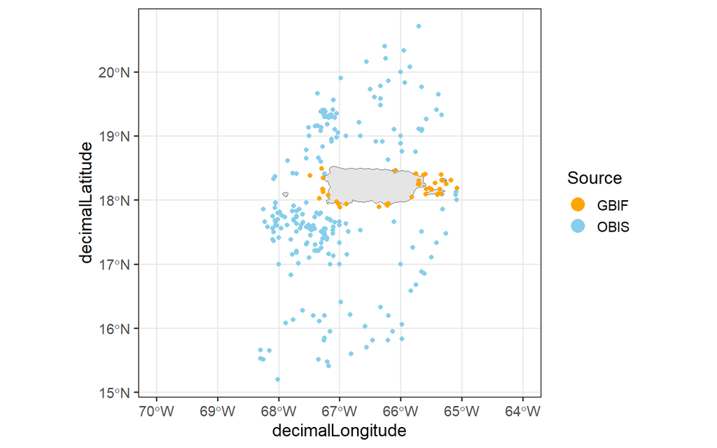

Select reproductive traits for *Coryphaena hippurus* from FishBase.

| Term | Value |
| --- | --- |
| Species | Coryphaena hippurus |
| ReproMode | dioecism |
| Fertilization | external |
| Spawning | Variable throughout range |
| RepGuild1 | nonguarders |
| RepGuild2 | open water/substratum egg scatterers |
| ParentalCare | none |

#### Citations

- Bakış, Y., Wang, X. FishNet2 Marine Data. Published 2023-12-19. https://fishnet.tulane.edu/ipt/resource?r=fishnet2_obis.
- Kullander, S., OBIS Secretariat. Fishbase occurrences hosted by GBIF-Sweden. Published NA. http://ipt.obis.org/nonode/resource?r=fishbase_occurrence.
- Benson, A., Diaz, G. NOAA Southeast Fisheries Science Center (SEFSC) Fisheries Log Book System (FLS) Commercial Pelagic Logbook Data. Published 2021-08-25. https://ipt-obis.gbif.us/resource?r=sefsc_logbook.
- Garrison, L., Garrison, L., OBIS-SEAMAP. SEFSC Caribbean Survey 1995. Published 2021-09-08. http://ipt.env.duke.edu/resource?r=zd_11.
- OBIS (2024) Occurrence records of Coryphaena hippurus (Linnaeus, 1758) in the Puerto Rico EEZ [Dataset] (Available: Ocean Biodiversity Information System. Intergovernmental Oceanographic Commission of UNESCO. www.obis.org. Accessed:2024-04-19)
- GBIF Occurrence Download https://doi.org/10.15468/dl.8sjy3r Accessed from R via rgbif (https://github.com/ropensci/rgbif) on 2024-04-19